# Exam 1. Applied Data Mining

**Instruction**: You can scan your answers and submit it to Canvas. You can also type your answers and submit the documents to Canvas. The solutions for the similar problems are provided at each problem.

#### Problem 1

Calculate the impurity of all possible splits to decide the best vertical first split for the following dataset. Impurity can be measured by entropy or Gini-Index. A similar problem can be found at the example at the class slides (Link).

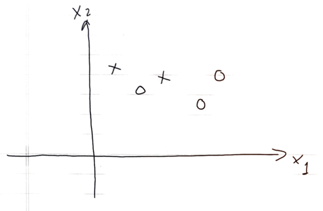

#### Problem 2

A similar problem and solution can be found here: Link

- Given the **training** data.

| Class | Sex | Survived |
| --- | --- | --- |
| 1 | 0 | 1 |
| 1 | 0 | 1 |
| 1 | 0 | 1 |
| 1 | 1 | 1 |
| 1 | 0 | 1 |
| 1 | 0 | 1 |
| 1 | 0 | 1 |
| 3 | 1 | 1 |
| 3 | 0 | 1 |
| 2 | 1 | 0 |
| 3 | 0 | 1 |
| 2 | 1 | 0 |
| 2 | 1 | 0 |
| 3 | 1 | 0 |
| 2 | 1 | 0 |
| 3 | 0 | 0 |
| 1 | 0 | 0 |
| 2 | 0 | 0 |
| 1 | 1 | 0 |
| 2 | 1 | 0 |

Using Gini Index as the measure for impurity to:

1. Grow the **maximum tree** with three leaves (a stopping rule!) on the data. Draw the (diagram of) tree.
2. Find the misclassification rate on training data of the maximal tree
3. Draw all the possible **subtrees**
4. Validate the maximal tree and all the subtrees on the following data to select the **optimal tree**. Note: if the chance of Survived is 1/2, predict `Survived`

| Class | Sex | Survived |
| --- | --- | --- |
| 1 | 0 | 1 |
| 1 | 1 | 1 |
| 3 | 1 | 0 |
| 2 | 0 | 0 |